# ggplot2 Elegant Graphics for Data Analysis

## 3.5 Exercises

1. Create a distribution() function specially designed for visualising continuous distributions. Allow the user to supply a dataset and the name of a variable to visualise. Let them choose between histograms, frequency polygons, and density plots. What other arguments might you want to include?

두가지 방법이 있다.

첫번째 방법은 aes를 직접 입력하는것.

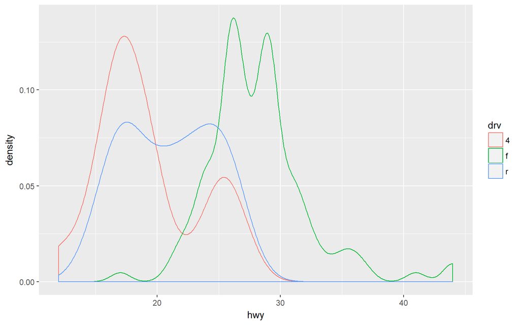

```r
distribution <- function(data, mapping, type = "density", ...) {


  if(type == "histogram") {
    ggplot(data, mapping) +
      geom_histogram(...)
  }
  else if (type == "freq_polygon"){
    ggplot(data, mapping) +
      geom_freqpoly(...)
  }
  else
    ggplot(data, mapping) +
      geom_density(...)
}

df <- data.frame(value = rnorm(seq(-3, 3,by = 0.01)))
df <- df %>%
  mutate(x = rep(c("a","b","c"), length = nrow(df)))
distribution(mpg, aes(hwy, colour = drv), alpha = 1/3)
```

두번째는 원하는 변수의 분포를 aes를 입력 하지 않아도 되는 방법.

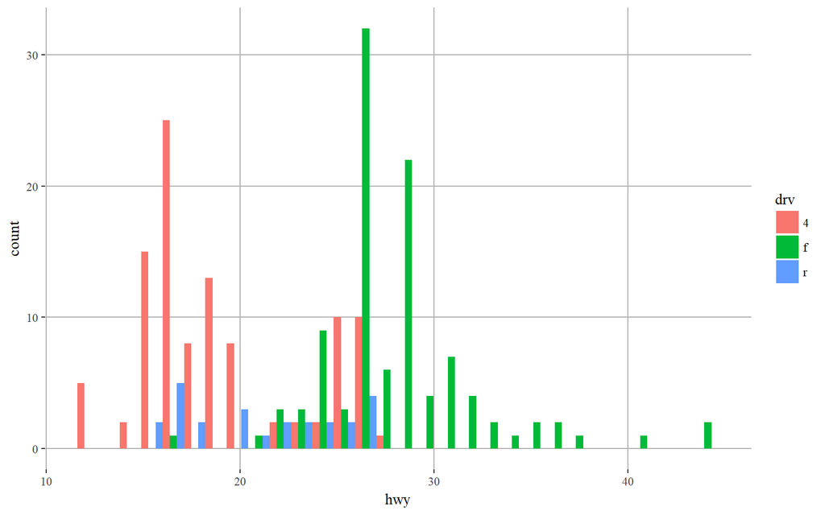

```r
distribution <- function(df, var, fun, ...) {
  var <- rlang::quo_text(enquo(var))
  g <- ggplot(df, aes_string(var)) + theme_tufte() +
    theme(
      panel.grid.major = element_line(colour = "grey70")
    )

   if(fun == "histogram") {
      g + geom_histogram(...)
  }
  else if (fun == "freq_polygon"){
      g + geom_freqpoly(...)
  }
  else
    g + geom_density(...)
}
distribution(mpg, hwy, "histogram", aes(fill = drv), position = "dodge")
```

2. What additional arguments should pcp() take? What are the downsides of how … is used in the current code?
1. 어떻게 쓰는지 이해하기 어렵다.
2. documentation에 쓰여 있지 않은 특징이 있을 수 있다.
3. 스펠링을 틀려도 에러를 발생시키지 않는다.(pcp에서는 아님)

```r
#c에 해당하는 예
sum(1, 2, NA, na.mr = TRUE)
```

```
## [1] NA
```

3. Advanced: why doesn’t this code work? How can you fix it?

```r
f <- function() {
  levs <- c("2seater", "compact", "midsize", "minivan", "pickup",
  "subcompact", "suv")
  piechart3(mpg, factor(class, levels = levs))
}
f()
```

```
#> Error in factor(class, levels = levs): object 'levs' not found
```

Sol.1)우선 함수를 살펴보자. levs가 접근 가능한 환경에 있지 않다. levs를 매개변수로 받아버리자.

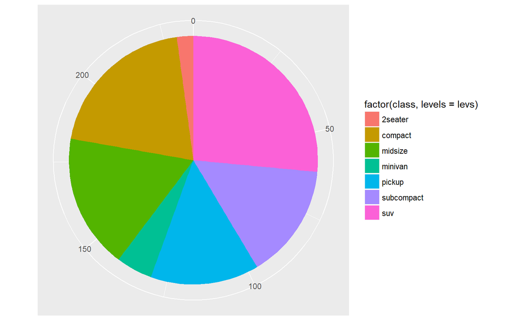

```r
f <- function(levs) {
  piechart3(mpg, factor(class, levels = levs))
}
levs <- c("2seater", "compact", "midsize", "minivan", "pickup",
          "subcompact", "suv")
f(levs)
```

Sol.2)enviornment를 활용 … 인자와 enviornment인자를 추가시켰다.

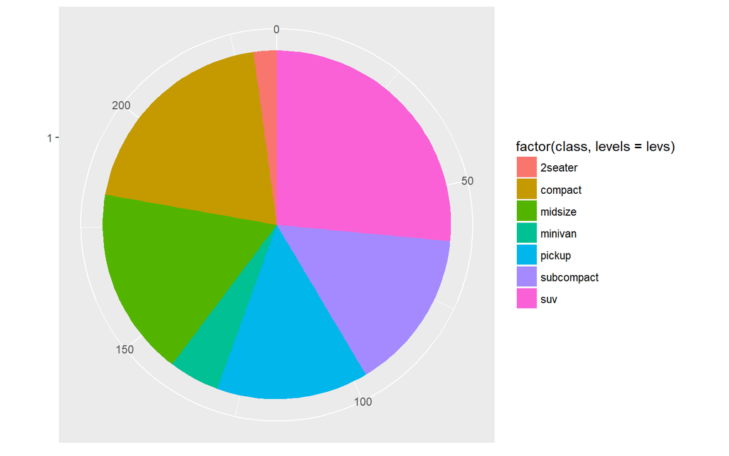

```r
 piechart <- function(data, mapping, ...) {
    ggplot(data, mapping, ...) +
      geom_bar(width = 1) +
      coord_polar(theta = "y") +
      xlab(NULL) +
      ylab(NULL)
  }
#piechart(mpg, aes(factor(1), fill = class)) #오류 없음

  piechart3 <- function(data, var, ...) {
    piechart(data, aes_(~factor(1), fill = substitute(var)), ...)
  }
#piechart3(mpg, class) + theme(legend.position = "none") #오류 없음
f <- function() {
     .e <- environment()
  levs <- c("2seater", "compact", "midsize", "minivan", "pickup",
  "subcompact", "suv")
  piechart3(mpg, factor(class, levels = levs), environment = .e)
}
f()
```

levs가 f바깥에 있는 경우 : 오류 x levs가 f바깥에 있고 f의 인자가 levs = levs인 경우 : 오류 levs가 f바깥에 있고 .e도 바깥에 있는 경우 : 오류 x

advanced-R 8장을 참고하라.

# 4 Functional Programming

**reference** : http://rpubs.com/cardiomoon/253966

http://adv-r.had.co.nz/Functional-programming.html

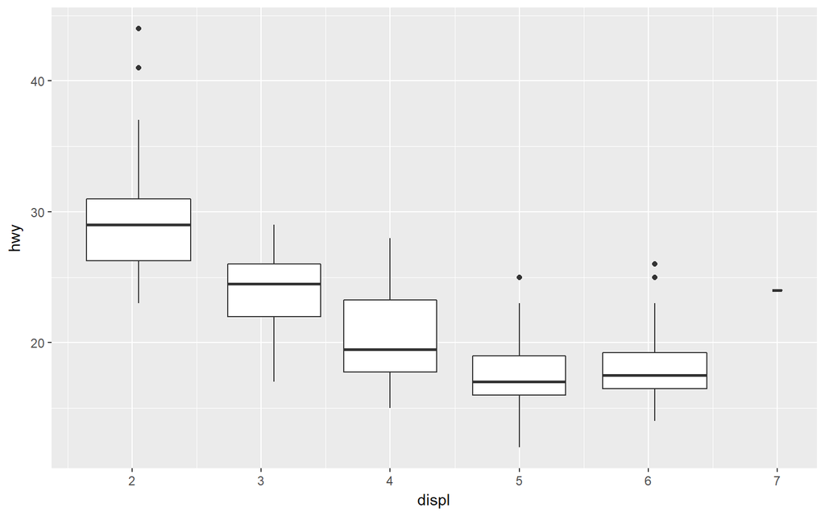

```r
geoms <- list(
  geom_point(),
  geom_boxplot(aes(group = cut_width(displ, 1))),
  list(geom_point(), geom_smooth())
)
p <- ggplot(mpg, aes(displ, hwy))
lapply(geoms, function(g) p + g)
```

### 4.0.1 Redue

base의 `Reduce`를 purr의 `reduce`로 대체.

```r
pasteadd <- function(...) {
  paste(..., sep = "+")
}
purrr::reduce(month.name, pasteadd)
```

```
## [1] "January+February+March+April+May+June+July+August+September+October+November+December"
```

## 4.1 Exercises

1. How could you add a geom point() layer to each element of the following list?

```r
plots <- list(
  ggplot(mpg, aes(displ, hwy)),
  ggplot(diamonds, aes(carat, price)),
  ggplot(faithfuld, aes(waiting, eruptions, size = density))
)
```

lapply를 이해하면 쉽다.

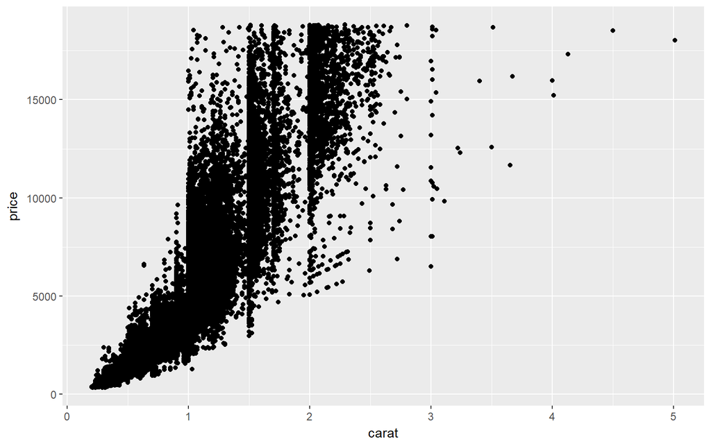

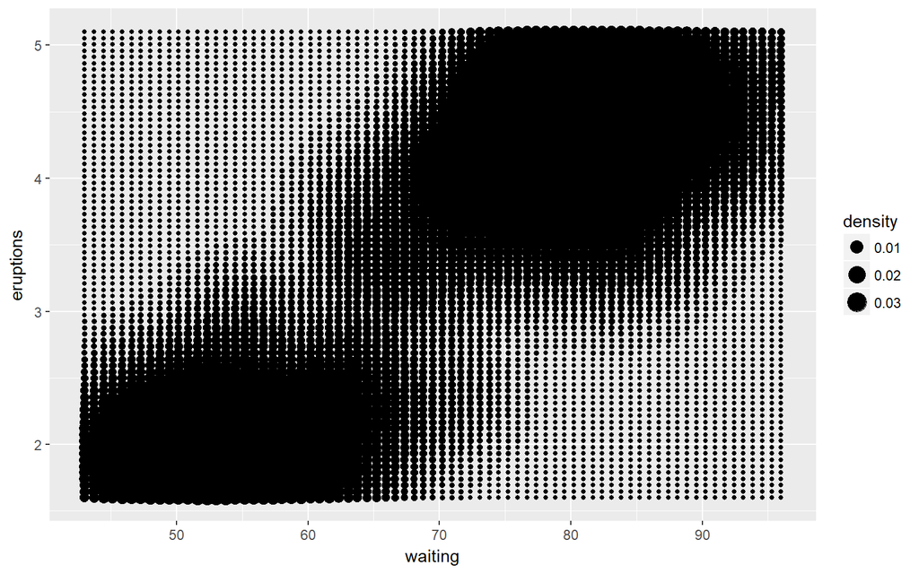

```r
plots <- list(
  ggplot(mpg, aes(displ, hwy)),
  ggplot(diamonds, aes(carat, price)),
  ggplot(faithfuld, aes(waiting, eruptions, size = density))
)
g <- geom_point()
lapply(plots, function(p) p + g)
```

3번째 그림에 scale_size_area() 레이어를 어떻게 추가시킬까?

2. What does the following function do? What’s a better name for it?

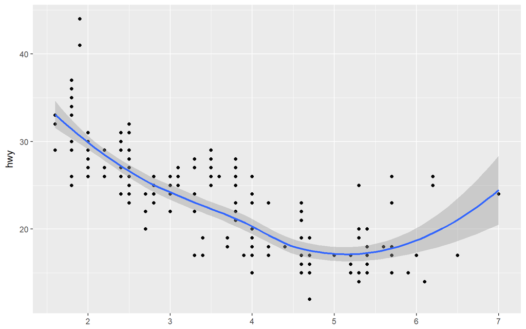

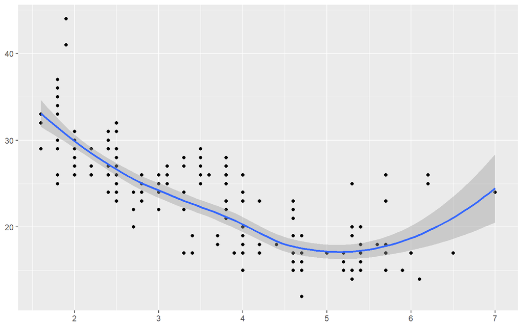

```r
mystery <- function(...) {
  Reduce('+', list(...), accumulate = TRUE)
}
mystery(
  ggplot(mpg, aes(displ, hwy)) + geom_point(),
  geom_smooth(),
  xlab(NULL),
  ylab(NULL)
)
```

Reduce 함수를 이해하면 충분히 풀 수 있는 문제.

# 5 Summary

- tidyverse패키지의 함수를 사용할 때 인자를 변수로 접근하고 싶을 때(즉, 변수 간접 참조) NSE 가 아닌 standard-evaluation을 사용하는 함수들을 이용하자.(e.g. aes_(), gather_(),…) 또한 quote(), substitue(), “~” 도 필요시 이용하자.
- 코드의 길이를 줄이고 여러 플랏을 출력시키고 싶을때 list, lapply, Reduce를 활용하자.
- ggplot의 인자들을 변수로 접근하고 싶을 때 ggplot의 스코프 룰에 주의하자.
- 모든 조합을 df로 반환하는 함수 : `expand.grid`
- 여러 열을 합치는 함수 : `unite()`
- 가변인자를 매개변수로 받아와서 리스트로 변환한 뒤, `do.call(function, params)`를 사용하여 함수의 유연성을 증가시킨다. 또한 `modifyList()`를 사용하면 두 객체 모두 적용할 매개변수와 하나의 객체만 적용시킬 매개변수를 구분할 수 있다.
- plot 환경에 대한 이해
- reduce에 대한 이해